# Compito (con soluzioni)

Scrivere in stampatello

| COGNOME | $\LARGE\square$ | $\LARGE\square$ | $\LARGE\square$ | $\LARGE\square$ | $\LARGE\square$ | $\LARGE\square$ | $\LARGE\square$ | $\LARGE\square$ | $\LARGE\square$ | $\LARGE\square$ | $\LARGE\square$ | $\LARGE\square$ | $\LARGE\square$ | $\LARGE\square$ | $\LARGE\square$ | $\LARGE\square$ | $\LARGE\square$ | $\LARGE\square$ | $\LARGE\square$ | $\LARGE\square$ |
| --- | --- | --- | --- | --- | --- | --- | --- | --- | --- | --- | --- | --- | --- | --- | --- | --- | --- | --- | --- | --- |
| NOME | $\LARGE\square$ | $\LARGE\square$ | $\LARGE\square$ | $\LARGE\square$ | $\LARGE\square$ | $\LARGE\square$ | $\LARGE\square$ | $\LARGE\square$ | $\LARGE\square$ | $\LARGE\square$ | $\LARGE\square$ | $\LARGE\square$ | $\LARGE\square$ | $\LARGE\square$ | $\LARGE\square$ | $\LARGE\square$ | $\LARGE\square$ | $\LARGE\square$ | $\LARGE\square$ | $\LARGE\square$ |
| Matricola | $\LARGE\square$ | $\LARGE\square$ | $\LARGE\square$ | $\LARGE\square$ | $\LARGE\square$ | $\LARGE\square$ | $\LARGE\square$ | $\LARGE\square$ | $\LARGE\square$ | $\LARGE\square$ | $\LARGE\square$ | $\LARGE\square$ | $\LARGE\square$ | $\LARGE\square$ | $\LARGE\square$ | $\LARGE\square$ | $\LARGE\square$ | $\LARGE\square$ | $\LARGE\square$ | $\LARGE\square$ |
| CDL | $\LARGE\square$ | $\LARGE\square$ | $\LARGE\square$ | $\LARGE\square$ | $\LARGE\square$ |  |  |  |  |  |  |  |  |  |  |  |  |  |  |  |

### Esercizio 1

Su un campione di $160$ famiglie della provincia di Modena è stato rilevato l’investimento annuo in prodotti finanziari (espresso in migliaia di euro). Qui di seguito la distribuzione delle frequenze cumulate:

| $[\text{x}_j,$ | $\text{x}_{j+1})$ | $F_j$ |
| --- | --- | --- |
| 0.0 | 3.5 | 0.0813 |
| 3.5 | 5.0 | 0.5000 |
| 5.0 | 6.5 | 0.9188 |
| 6.5 | 10.0 | 1.0000 |

1.a (**Punti 14 su 103 (4.08 su 30)**) Disegnare l’istogramma di densità percentuale.

| $[\text{x}_j,$ | $\text{x}_{j+1})$ | $n_j$ | $f_j$ | $b_j$ | $h_j$ |
| --- | --- | --- | --- | --- | --- |
| 0.0 | 3.5 | 13 | 0.0813 | 3.5 | 2.321 |
| 3.5 | 5.0 | 67 | 0.4188 | 1.5 | 27.917 |
| 5.0 | 6.5 | 67 | 0.4188 | 1.5 | 27.917 |
| 6.5 | 10.0 | 13 | 0.0813 | 3.5 | 2.321 |
|  |  | 160 | 1.0000 | 10.0 |  |

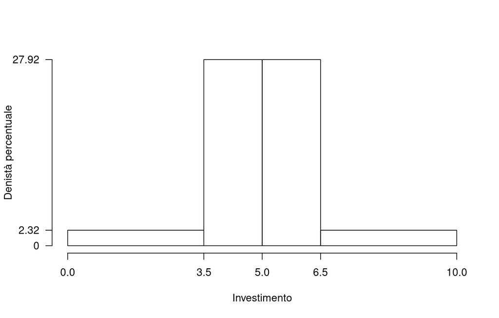

1.b (**Punti 3 su 103 (0.87 su 30)**) Quante famiglie investono meno di 4.5 mila euro all’anno?

$$\begin{eqnarray*}
\#(X<4.5)
&=& 160(\frac1{100}(4.5-3.5)\times27.9167+0.0813)\\
&=& 57.6667
\end{eqnarray*}$$

1.c (**Punti 2 su 103 (0.58 su 30)**) Che relazione dobbiamo aspettarci tra media e mediana?

1.d (**Punti 2 su 103 (0.58 su 30)**) La spesa media è pari a $\bar x=4.9926$, mentre la SD è pari a $SD=1.5124$. Se ogni famiglia diminuisse il proprio investimento del 2%, quanto varrebbero la media e la SD dei dati così trasformati?

### Esercizio 2

L’urna $A$ contiene 4 palline numerate: $\fbox{-1},\fbox{0},\fbox{0},\fbox{+1}$.

L’urna $B$ contiene 3 palline numerate: $\fbox{0},\fbox{1},\fbox{2}$.

Si estrae dall’urna $A$ e dall’urna $B$ e si *sommano* i due numeri

2.a (**Punti 14 su 103 (4.08 su 30)**) Calcolare la probabilità che la somma dei numeri sia maggiore uguale a 2.

$$\begin{array}{ r|rrrrrr }
& -1 ;&\color{blue}{ \frac{ 1 } { 4 }} & 0
;&\color{blue}{ \frac{ 2 } { 4 }} & 1 ;&\color{blue}{ \frac{
1 } { 4 }} \\
\hline
1 ;\color{blue}{ 1 / 3 }& 0;&\color{red}{\frac{1}{12}}&
1;&\color{red}{\frac{2}{12}}& 2;&\color{red}{\frac{1}{12}}\\
2 ;\color{blue}{ 1 / 3 }& 1;&\color{red}{\frac{1}{12}}&
2;&\color{red}{\frac{2}{12}}& 3;&\color{red}{\frac{1}{12}}\\
\end{array}$$

E ricaviamo la distribuzione di, $X$

2.b (**Punti 3 su 103 (0.87 su 30)**) Calcolare la probabilità che la somma sia maggiore uguale a 1 dato che dall’urna $A$ è uscito $\fbox{0}$.

Dalla definizione stessa di probabilità condizionata
$$\begin{eqnarray*}
P(X\geq 1|X_A=0)&=&\frac{P(\{X\geq
1\}\cap\{X_A=0\})}{P(\{X_A=0\})}\\
&=&\frac{2/12+2/12}{2/4}\\
&=&4/12\cdot4/2\\
&=&0.6667
\end{eqnarray*}$$

2.c (**Punti 3 su 103 (0.87 su 30)**) Sia $X\sim \text{Pois}(10)$ e $Y\sim\text{Binom}(n,0.5)$. Sia
$$W=X-Y$$
Calcolare il valore atteso $E(W)$ e la varianza $V(W)$ di $W$.

Osserviamo
$$\begin{align*}
E(X)&=10 &E(Y)&=n\cdot 0.5\\
V(X)&=10 &V(Y)&=n\cdot0.5(1-0.5)
\end{align*}$$
e quindi
$$\begin{eqnarray*}
E(W)&=&E(X)-E(Y)\\
&=&10-n\cdot 0.5\\
V(W)&=&V(X)+V(Y),\qquad\text{se e solo se $X$ e $Y$ sono
indipendenti}\\
&=&10+n\cdot 0.25
\end{eqnarray*}$$

2.d (**Punti 2 su 103 (0.58 su 30)**) Siano $X_1,...,X_6$, $6$ variabili casuali IID, tali che
$$X_i\sim N\left(2.5,3^2\right).$$
Come si distribuisce
$$Y=\sum_{i=1}^6\left(\frac{X_i-2.5}{3}\right)^2~~?$$

Si osserva
$$Z_i=\frac{X_i-2.5}{3}\sim N(0,1)$$
e quindi
$$Y=(Z_1^2+...+Z_6^2)\sim\chi_6^2$$

### Esercizio 3

(**Punti 14 su 103 (4.08 su 30)**) Si lancia un dado perfetto, si vince se esce un numero maggiore o uguale a 5. Si gioca $n=64$ volte, qual è la probabilità di vincere più di 23 volte su 64 giocate?

$$\pi=\frac 2 6=\frac 13$$
la probabilità di vincere all’estrazione $i$, e quindi $X_i\sim\text{Ber}(\pi)$

$$\begin{eqnarray*}
E(X_i)&=&\pi\\
V(X_i)&=&\pi(1-\pi)
\end{eqnarray*}$$

In virtù del TCL della somma di n VC IID

**Teorema del Limite Centrale (somma di Bernoulli)**

Siano $X_1$,…,$X_n$, $n=64$ VC IID, tc $X_i\sim\text{Ber}(\pi=0.3333)$$,\forall i$, posto:
$$S_n = X_1 + ... + X_n$$
allora:
$$\begin{eqnarray*}
S_n & \mathop{\sim}\limits_{a}& N(n\pi,n\pi(1-\pi)) \\
&\sim & N(64\cdot0.3333,64\cdot0.3333\cdot(1-0.3333)) \\
&\sim & N(21.33,14.22)
\end{eqnarray*}$$

$$\begin{eqnarray*}
P(S_n > 23)
&=& P\left( \frac {S_n - n\pi}{\sqrt{n\pi(1-\pi)}} > \frac
{23 - 21.3333}{\sqrt{14.2222}} \right) \\
&=& P\left( Z > 0.44\right) \\ &=&
1-P(Z< 0.44 )\\
&=& 1-\Phi( 0.44 ) \\ &=& 0.33
\end{eqnarray*}$$

### Esercizio 4

4.a (**Punti 3 su 103 (0.87 su 30)**) Sia $\hat\sigma^2$ lo stimatore di massima verosimiglianza per il parametro $\sigma^2$ della normale. $\hat\sigma^2$ è corretto? Quanto vale la sua distorsione?

No, $\hat\sigma^2$ non è corretto
$$E(\hat\sigma^2)=\frac{n-1}n\sigma^2$$
e quindi
$$B(\hat\sigma^2)=|E(\hat\sigma^2)-\sigma^2|=\frac {\sigma^2}n$$

4.b (**Punti 3 su 103 (0.87 su 30)**) Descrivere la tavola della verità di un test.

4.c (**Punti 3 su 103 (0.87 su 30)**) In uno studio clinico si è osservato l’effeto sul numero di anticorpi su due gruppi trattati con un farmaco differente. Si è osservato $\hat\mu_1=10.2$, $\hat\sigma_1=1.12$ e $\hat\mu_2=15.6$, $\hat\sigma_2=3.72$. Posto a test
$$\begin{cases}
H_0:\sigma_1=\sigma_2\\
H_1:\sigma_1\ne \sigma_2
\end{cases}$$
è risultato $p_\text{value}=0.21$. Quale test dovremmo usare per testare la differenza tra le medie?

### Esercizio 5

Nel comune $A$ si è condotta un’intervista per conoscere l’opinione dei cittadini sulla presenza di un inceneritore. Sono state intervistate 25 persone a cui è stato chiesto di esprimete l’opinione in una scala da zero a 100. È risultato un punteggio medio pari a $\hat\mu_A=72.1$ con una standard deviation $\hat\sigma_A=3.4$

$$S =\sqrt{\frac {n}{n-1}}\cdot\hat\sigma =
\sqrt{\frac { 25 }{ 24 }}\cdot 3.4 = 3.4701$$
$$\begin{eqnarray*}
Idc: & & \hat\mu \pm t_{n-1;\alpha/2} \times
\frac{S}{\sqrt{n}} \\
& & 72.1 \pm 2.064 \times \frac{ 3.4701 }{\sqrt{ 25 }}
\\
& & 72.1 \pm 2.064 \times 0.694 \\
& & [ 70.67 , 73.53 ]
\end{eqnarray*}$$

$\fbox{A}$ FORMULAZIONE DELLE IPOTESI

$$\begin{cases}
H_0:\mu_\text{A} = \mu_\text{ B}\text{}\\
H_1:\mu_\text{A} \neq \mu_\text{ B}\text{}
\end{cases}$$
Siccome $H_1$ è bilaterale, considereremo $\alpha/2$, anziché $\alpha$

$\fbox{B}$ SCELTA E CALCOLO STATISTICA-TEST, $T$

L’ipotesi è di omogeneità e quindi calcoliamo:

$$S_p^2=\frac{n_\text{A}\hat\sigma^2_\text{A}+n_\text{B}\hat\sigma^2_\text{B}}{n_\text{A}+n_\text{B}-2}
=
\frac{25\cdot3.4^2+24\cdot3.3^2}{25+24-2}=11.7098$$

$$\begin{eqnarray*}
\frac{\hat\mu_\text{A} - \hat\mu_\text{B}}
{\sqrt{\frac {S^2_p}{n_\text{A}}+\frac
{S^2_p}{n_\text{B}}}}&\sim&t_{n_\text{A}+n_\text{B}-2}\\
t_{\text{obs}}
&=& \frac{ (72.1- 69.6)}
{\sqrt{\frac{11.7098}{25}+\frac{11.7098}{24}}}
= 2.5565\, .
\end{eqnarray*}$$

$\fbox{C}$ DECISIONE Dalle tavole si ha $t_{(25+24-2);\, 0.025} = 2.0117$.
$$t_{\text{obs}} = 2.5565
> t_{47;\, 0.025} = 2.0117$$

**Graficamente**

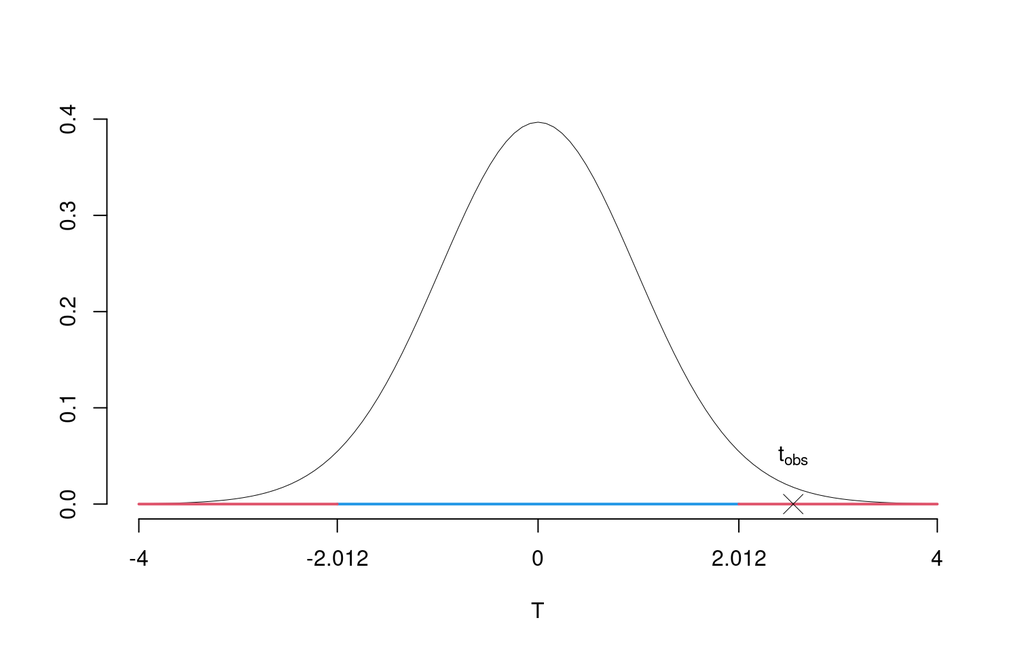

Il $p_{\text{value}}$ è
$$P(|T_{n1+n2-2}|>|t_{\text{obs}}|)=2P(T_{n1+n2-2}>|t_{\text{obs}}|)=2P(T_{n1+n2-2}>|
2.5565 |)= 0.01386$$

### Esercizio 6

In uno studio sul reddito, in un campione di $n=50$ individui, sono state analizzati il livello di istruzione (in anni di studio, $X$) e il reddito annuale (in migliaia di euro, $Y$). Si osservano le seguenti statistiche, $\sum_{i=1}^{50}x_i=546$, $\sum_{i=1}^{50}y_i=1579$, $\sum_{i=1}^{50}x_i^2=6654$, $\sum_{i=1}^{50}y_i^2=52221$ e $\sum_{i=1}^{50}x_iy_i=18216$.

6.a (**Punti 14 su 103 (4.08 su 30)**) Si è osservato $x_3=10$ e $y_3=31.84$, stimare il modello di regressione dove $Y$ viene spiegata da $X$ e calcolare il residuo per il punto $i=3$.

$$\begin{eqnarray*}
\bar x &=&\frac 1 n\sum_{i=1}^n x_i = \frac {1}{50} 546= 10.92\\
\bar y &=&\frac 1 n\sum_{i=1}^n y_i = \frac {1}{50} 1579=
31.58\\
\hat\sigma_X^2&=&\frac 1 n\sum_{i=1}^n x_i^2-\bar x^2=\frac
{1}{50} 6654 -10.92^2=13.8336\\
\hat\sigma_Y^2&=&\frac 1 n\sum_{i=1}^n y_i^2-\bar y^2=\frac
{1}{50} 52221 -31.58^2=47.1236\\
\text{cov}(X,Y)&=&\frac 1 n\sum_{i=1}^n x_i~y_i-\bar x\bar
y=\frac {1}{50} 18216-10.92\cdot31.58=19.4674\\
\hat\beta_1 &=& \frac{\text{cov}(X,Y)}{\hat\sigma_X^2} \\
&=& \frac{19.4674}{13.8336} = 1.4073\\
\hat\beta_0 &=& \bar y - \hat\beta_1 \bar x\\
&=& 31.58-1.4073\times 10.92=16.2128
\end{eqnarray*}$$

$$\begin{eqnarray*}
\hat y_i &=&\hat\beta_0+\hat\beta_1 x_i=\\
&=& 16.21 + 1.4073 \times 10 = 30.29 \\
\hat \varepsilon_i &=& y_i-\hat y_i\\
&=& 31.84 - 30.29 = 1.555
\end{eqnarray*}$$

6.b (**Punti 3 su 103 (0.87 su 30)**) Il modello si adatta bene ai dati?

$$\begin{eqnarray*}
r&=&\frac{\text{cov}(X,Y)}{\sigma_X\sigma_Y}=\frac{ 19.47 }{
3.719 \times 6.865 }= 0.7625 \\r^2&=& 0.5814 < 0.75
\end{eqnarray*}$$
Il modello **non** si adatta bene ai dati.

6.c (**Punti 2 su 103 (0.58 su 30)**) Stimare lo Standard Error di $\hat\beta_0$.

$$\begin{eqnarray*}
\hat{\sigma_\varepsilon}^2&=&(1-r^2)\hat\sigma_Y^2\\
&=& (1-0.5814)\times47.1236\\
&=& 19.728\\
S_\varepsilon^2 &=& \frac{n} {n-2}
\hat{\sigma_\varepsilon}^2\\
&=& \frac{50} {50-2} \hat{\sigma_\varepsilon}^2 \\
&=& \frac{50} {50-2} \times 19.728 = 20.55
\end{eqnarray*}$$

E quindi

$$\begin{eqnarray*}
V(\hat\beta_{0}) &=& \sigma_{\varepsilon}^{2} \left( \frac{1}
{n} + \frac{\bar{x}^{2}} {n \hat{\sigma}^{2}_{X}} \right)\\
\widehat{V(\hat\beta_{0})} &=& S_{\varepsilon}^{2}\left(
\frac{1} {n} + \frac{\bar{x}^{2}} {n \hat{\sigma}^{2}_{X}} \right)\ \\
&=& 20.55\times\left( \frac{1} {50} + \frac{10.92^{2}}
{50\times 13.8336} \right)\\
\widehat{SE(\hat\beta_{0})} &=& \sqrt{3.9538}\\
&=& 1.9884
\end{eqnarray*}$$

6.d (**Punti 2 su 103 (0.58 su 30)**) Definire il qq-plot.

6.e (**Punti 2 su 103 (0.58 su 30)**) Se in un modello di regressione $r=0.35$, $\hat\sigma_X=1.2$ e $\hat\sigma_X=0.5$, quanto varrà $\hat\beta_1$, il coefficiente angolare della retta di regressione in cui $Y$ è spiegata da $X$?